# challenge01

Jyhreh Johnson

2/22/2022

Challenge 1

1. Using the {tidyverse} read_csv() function, load the “IMDB-movies.csv” dataset from this URL as a “tibble” named d

```r
library(tidyverse)
f <- "https://raw.githubusercontent.com/difiore/ada-2022-datasets/main/IMDB-movies.csv"
d <- read_csv(f, col_names = TRUE)
```

2. Use a one-line statement to filter the dataset to include just movies from 1920 to 1979 and movies that are between 1 and 3 hours long (runtimeMinutes >= 60 and runtimeMinutes <= 180), and add a new column that codes the startYear into a new variable, decade (“20s,” “30s,” …“70s”). If you do this correctly, there should be 5651 movies remaining in the dataset.

```r
d <- d %>% filter(startYear %in% 1920:1979 & runtimeMinutes %in% 60:180)%>%
mutate(decade = case_when(
  startYear %in% 1920:1929 ~ "20s",
  startYear %in% 1930:1939 ~ "30s",
  startYear %in% 1940:1949 ~ "40s",
  startYear %in% 1950:1959 ~ "50s",
  startYear %in% 1960:1969 ~ "60s",
  startYear %in% 1970:1979 ~ "70s",
))
head(d)
```

```
## # A tibble: 6 × 11
##   tconst    titleType primaryTitle startYear runtimeMinutes genres averageRating
##   <chr>     <chr>     <chr>            <dbl>          <dbl> <chr>          <dbl>
## 1 tt0010323 movie     The Cabinet…      1920             76 Fanta…           8.1
## 2 tt0011000 movie     Leaves From…      1920            167 Drama            6.7
## 3 tt0011130 movie     Dr. Jekyll …      1920             82 Drama…           7
## 4 tt0011237 movie     The Golem         1920             76 Fanta…           7.2
## 5 tt0011387 movie     The Last of…      1920             73 Actio…           6.7
## 6 tt0011439 movie     The Mark of…      1920            107 Adven…           7.1
## # … with 4 more variables: numVotes <dbl>, nconst <chr>, director <chr>,
## #   decade <chr>
```

3. Use {ggplot2} (which is part of {tidyverse}) to plot histograms of the distribution of runtimeMinutes for each decade.

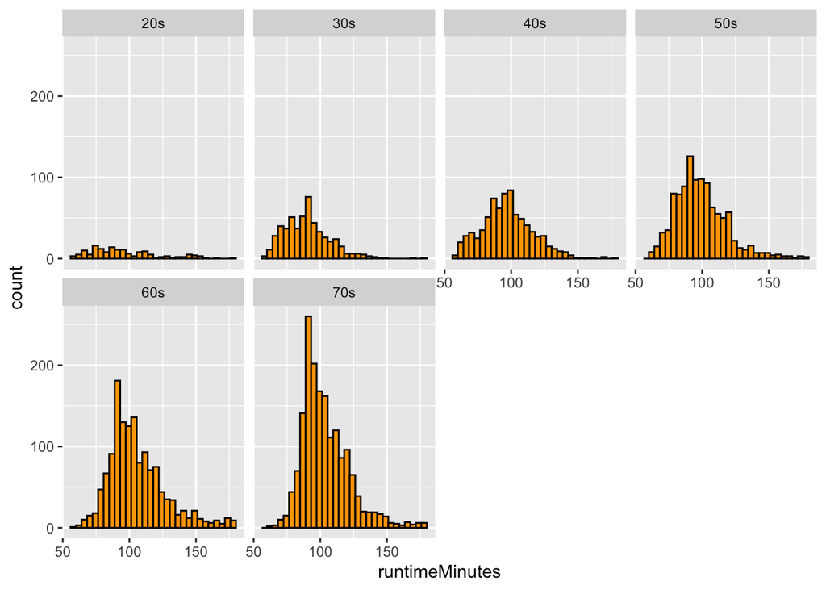

```r
library(dplyr)
library(mosaic)
library(ggplot2)

p <- ggplot(data = d, aes(x = runtimeMinutes)) +
     geom_histogram(stat = "bin", bins = 30,
                color = "black",
                fill = "orange") +
                facet_wrap(~decade, ncol = 4) #create ggplot
p #print ggplot
```

4. Use a one-line statement to calculate the population mean and population standard deviation in runtimeMinutes for each decade and save the results in a new dataframe called results.

```r
results <- d %>% group_by(decade)%>%
  summarize(
    pop_mean = mean(runtimeMinutes, na.rm=TRUE),
    pop_sd = sd(runtimeMinutes, na.rm=TRUE),
    pop_se = pop_sd/sqrt(100)
  )
results #population mean, standard deviation, & standard error
```

```
## # A tibble: 6 × 4
##   decade pop_mean pop_sd pop_se
##   <chr>     <dbl>  <dbl>  <dbl>
## 1 20s        96.3   26.2   2.62
## 2 30s        90.3   17.3   1.73
## 3 40s        97.2   19.1   1.91
## 4 50s        98.9   19.2   1.92
## 5 60s       106.    21.2   2.12
## 6 70s       104.    18.0   1.80
```

5. Draw a single sample of 100 movies, without replacement, from each decade and calculate the single sample mean and single sample standard deviation in runtimeMinutes for each decades. Recall that your single sample mean for each decade is an estimate of the population mean for each decade. Calculate for each decade the standard error around your estimate of the population mean runtimeMinutes based on the standard deviation and sample size (n=100 movies) of your single sample.

```r
n = 100 #set sample size of 100 movies
samp_byDecade <- group_by(d, decade)%>%
  sample_n(n, replace = FALSE)%>%
  summarize(
    samp_mean = mean(runtimeMinutes, na.rm = TRUE),
    samp_sd = sd(runtimeMinutes, na.rm = TRUE),
    samp_se = samp_sd/sqrt(n)
    ) #pull single sample from 100 movies for each decade
samp_byDecade #sample mean, standard deviation, & standard error
```

```
## # A tibble: 6 × 4
##   decade samp_mean samp_sd samp_se
##   <chr>      <dbl>   <dbl>   <dbl>
## 1 20s         97.9    27.0    2.70
## 2 30s         89.9    18.0    1.80
## 3 40s         96.7    19.5    1.95
## 4 50s         98.4    17.6    1.76
## 5 60s        108.     21.0    2.10
## 6 70s        103.     20.0    2.00
```

6. Compare these estimates to the actual population mean runtimeMinutes for each decade and to the calculated SE in the population mean for samples of size 100 based on the population standard deviation for each decade.

```r
comparison <- left_join(samp_byDecade, results, by = "decade") #After our discussion on Friday, I decided to use the left_join function
comparison
```

```
## # A tibble: 6 × 7
##   decade samp_mean samp_sd samp_se pop_mean pop_sd pop_se
##   <chr>      <dbl>   <dbl>   <dbl>    <dbl>  <dbl>  <dbl>
## 1 20s         97.9    27.0    2.70     96.3   26.2   2.62
## 2 30s         89.9    18.0    1.80     90.3   17.3   1.73
## 3 40s         96.7    19.5    1.95     97.2   19.1   1.91
## 4 50s         98.4    17.6    1.76     98.9   19.2   1.92
## 5 60s        108.     21.0    2.10    106.    21.2   2.12
## 6 70s        103.     20.0    2.00    104.    18.0   1.80
```

```r
#comp_estimates1 <- merge(x, results, by="decade") <- this also works
#print(comp_estimates)
```

7. Generate a sampling distribution of mean runtimeMinutes for each decade by [a] drawing 1000 samples of 100 movies from each decade and, for each sample, [b] calculating the mean runtimeMinutes and the standard deviation in runtimeMinutes for each decade.

[a] Generate a sampling distribution of mean runtimeMinutes for each decade

```r
reps = 1000 #set reps to 1000

samp_dist <- do(reps) * sample_n(group_by(d, decade),
                        n, replace = FALSE)%>%
                        group_by(decade)%>%
                        summarize(
                        samp_distMean = mean(~runtimeMinutes, na.rm = TRUE),
                        samp_distSd = sd(~runtimeMinutes, na.rm = TRUE))
#sampling distribution
```

8. Then, calculate the MEAN and the STANDARD DEVIATION of the sampling distribution of sample means for each decade (the former should be a very good estimate of the population mean, while the latter is another estimate of the standard error in our estimate of the population mean for a particular sample size) and plot a histogram of the sampling distribution for each decade.

[a] Calculate the mean and standard deviation of the sampling distribution of sample means for each decade

```r
#use aggregate() from Module 9
samp_distDecMeans <- aggregate(samp_distMean~decade, mean, data = samp_dist)
samp_distDecMeans #mean of sampling distribution by decade
```

```
##   decade samp_distMean
## 1    20s      96.29970
## 2    30s      90.35737
## 3    40s      97.20522
## 4    50s      98.98882
## 5    60s     105.63599
## 6    70s     103.81905
```

```r
samp_distDecSDs <- aggregate(samp_dist$samp_distMean, by = list(samp_dist$decade), FUN = sd) #standard deviation sampling distribution by decade

#fix the samp_distDecSDs to remove "Group.1" and "x" and replace them with "decade" & "sd"
names(samp_distDecSDs)[names(samp_distDecSDs) == "Group.1"] <- "decade"
names(samp_distDecSDs)[names(samp_distDecSDs) == "x"] <- "sd"
samp_distDecSDs
```

```
##   decade       sd
## 1    20s 1.566118
## 2    30s 1.607203
## 3    40s 1.766938
## 4    50s 1.831072
## 5    60s 2.048014
## 6    70s 1.756030
```

```r
merge_sampDist <- left_join(samp_distDecMeans,samp_distDecSDs, by = "decade")

merge_sampDist
```

```
##   decade samp_distMean       sd
## 1    20s      96.29970 1.566118
## 2    30s      90.35737 1.607203
## 3    40s      97.20522 1.766938
## 4    50s      98.98882 1.831072
## 5    60s     105.63599 2.048014
## 6    70s     103.81905 1.756030
```

[b] Plot a histogram of the sampling distribution for each decade **Note**: I tried to make the histograms in two ways to practice writing them on their own and using facet_wrap

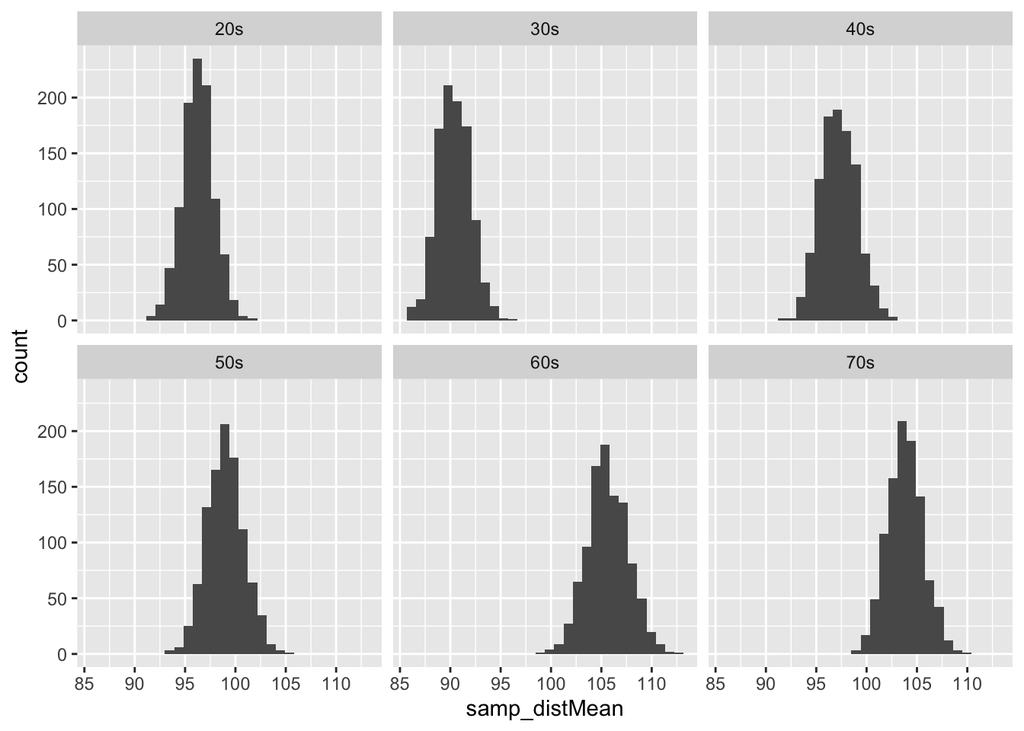

```r
samp_dist_plot <- ggplot(data = samp_dist, aes(x = samp_distMean)) + geom_histogram() + facet_wrap(~decade)

samp_dist_plot
```

```r
#twenties <- samp_dist[samp_dist$decade == "20s", ]
#histogram(~mean, data = twenties, main = "20s Sampling Distribution")
#thirties <- samp_dist[samp_dist$decade == "30s ", ] #Why is there no data in this variable?
#histogram(~mean, data = thirties, main = "30s Sampling Distribution") #Not plotting because thirties has no data
##forties <- samp_dist[samp_dist$decade == "40s", ]
#histogram(~mean, data = forties, main = "40s Sampling Distribution")
#fifties <- samp_dist[samp_dist$decade == "50s", ]
#histogram(~mean, data = fifties, main = "50s Sampling Distribution")
#sixties <- samp_dist[samp_dist$decade == "60s", ]
#histogram(~mean, data = sixties, main = "60s Sampling Distribution")
#seventies <- samp_dist[samp_dist$decade == "70s", ]
#histogram(~mean, data = seventies, main = "70s Sampling Distribution")
```

What shape does it have? -All histograms are in normal distribution

9. Finally, compare the standard error in runtimeMinutes for samples of size 100 from each decade [1] as estimated from your first sample of 100 movies, [2] as calculated from the known population standard deviations for each decade, and [3] as estimated from the sampling distribution of sample means for each decade.

**Note**:Previously I tried to calculate the standard error in my code for (7) creating the sampling distribution but I found that I couldn’t call the samp_se within that function so I decided to calculate the SE for each decade here

```r
SE_20s <- (samp_distDecMeans[1,2])/sqrt(reps)
SE_30s <- (samp_distDecMeans[2,2])/sqrt(reps)
SE_40s <- (samp_distDecMeans[3,2])/sqrt(reps)
SE_50s <- (samp_distDecMeans[4,2])/sqrt(reps)
SE_60s <- (samp_distDecMeans[5,2])/sqrt(reps)
SE_70s <- (samp_distDecMeans[6,2])/sqrt(reps)
decade <- c("20s", "30s", "40s", "50s", "60s", "70s")
samp_distSE <- c(SE_20s, SE_30s,SE_40s,SE_50s,SE_60s,SE_70s)
samp_distSEs <- data.frame(decade, samp_distSE)

comparison2 <- left_join(comparison, samp_distSEs, by = "decade") %>%
  select(decade, pop_se, samp_se, samp_distSE)

comparison2
```

```
## # A tibble: 6 × 4
##   decade pop_se samp_se samp_distSE
##   <chr>   <dbl>   <dbl>       <dbl>
## 1 20s      2.62    2.70        3.05
## 2 30s      1.73    1.80        2.86
## 3 40s      1.91    1.95        3.07
## 4 50s      1.92    1.76        3.13
## 5 60s      2.12    2.10        3.34
## 6 70s      1.80    2.00        3.28
```